# DATA 2401 Group Project

Thu Nguyen and Minh Le

# Charging Forward: A Data-Driven Look at Electric Vehicles Population (in the State of Washington)

## Team members: [Minh Le](https://quangnhatm1.github.io/) and Thu Nguyen

[figure not shown]

# **I. Introduction**

### Which are electric vehicles ?

Electric vehicles are referred to as battery electric vehicles (BEVs) and plug-in hybrid electric vehicles (PHEVs), which improves vehicle efficiency.

### Below is the data set provided by Washington State Department of Licensing:

*Link to view/download the dataset: [EV Dataset](https://data.wa.gov/api/views/f6w7-q2d2/rows.csv?accessType=DOWNLOAD)*

| County | City | State | Postal.Code | Model.Year | Make | Model | Electric.Vehicle.Type | Electric.Range | Electric.Utility |
| --- | --- | --- | --- | --- | --- | --- | --- | --- | --- |
| King | Seattle | WA | 98178 | 2019 | TESLA | MODEL 3 | Battery Electric Vehicle (BEV) | 220 | CITY OF SEATTLE - (WA)\|CITY OF TACOMA - (WA) |
| Kitsap | Poulsbo | WA | 98370 | 2020 | TESLA | MODEL Y | Battery Electric Vehicle (BEV) | 291 | PUGET SOUND ENERGY INC |
| Kitsap | Olalla | WA | 98359 | 2023 | HYUNDAI | IONIQ 5 | Battery Electric Vehicle (BEV) | 0 | PUGET SOUND ENERGY INC |
| Kitsap | Seabeck | WA | 98380 | 2021 | BMW | X5 | Plug-in Hybrid Electric Vehicle (PHEV) | 30 | PUGET SOUND ENERGY INC |
| Thurston | Rainier | WA | 98576 | 2023 | TOYOTA | RAV4 PRIME | Plug-in Hybrid Electric Vehicle (PHEV) | 42 | PUGET SOUND ENERGY INC |
| Thurston | Olympia | WA | 98502 | 2012 | TESLA | MODEL S | Battery Electric Vehicle (BEV) | 265 | PUGET SOUND ENERGY INC |
| King | Bellevue | WA | 98004 | 2017 | BMW | I3 | Battery Electric Vehicle (BEV) | 81 | PUGET SOUND ENERGY INC\|\|CITY OF TACOMA - (WA) |
| Snohomish | Marysville | WA | 98271 | 2022 | BMW | 330E | Plug-in Hybrid Electric Vehicle (PHEV) | 22 | PUGET SOUND ENERGY INC |
| King | Kirkland | WA | 98034 | 2018 | TESLA | MODEL 3 | Battery Electric Vehicle (BEV) | 215 | PUGET SOUND ENERGY INC\|\|CITY OF TACOMA - (WA) |
| King | Redmond | WA | 98052 | 2018 | TESLA | MODEL 3 | Battery Electric Vehicle (BEV) | 215 | PUGET SOUND ENERGY INC\|\|CITY OF TACOMA - (WA) |

[output cut: 11989 more lines]

### Ready to Lauch the Data

### Our data: What’s in it?

*It includes key attributes such as:*

- Location details (County, City, State, Postal Code).
- Vehicle specifications (Model Year, Make, Model).
- EV classification (Electric Vehicle Type, Electric Range).
- Electric utility provider.

# Explore this data!

*To effectively analyze this data, my team has created the following questions could be explored:*

1. **How are electric vehicle (EV) types distributed across Washington?**
2. **Which are the top 10 most common EV makes in Washington?**
3. **What are the top 10 most common EV models in Washington?**
4. **What Are the Most Preferred Electric Utility Providers for EV Owners?**
5. **How does EV adoption vary by county? How does the distribution of electric vehicle types vary among the top five counties with the highest EV adoption?**
6. **What trends can be observed in EV registrations over different model years?**
7. **Which cities have the highest number of registered electric vehicles, and how can spatial mapping illustrate all of Washington cities in EV adoption?**
8. **Are certain EV manufacturers dominant in specific counties or regions?**

This expanded set of questions will help uncover deeper insights into EV adoption trends and geographic patterns in Washington. Would you guys want to add more questions for me to analyze this beautiful data? 😊

# **II. Analyzing Dataset**

### How are electric vehicle (EV) types distributed across Washington?

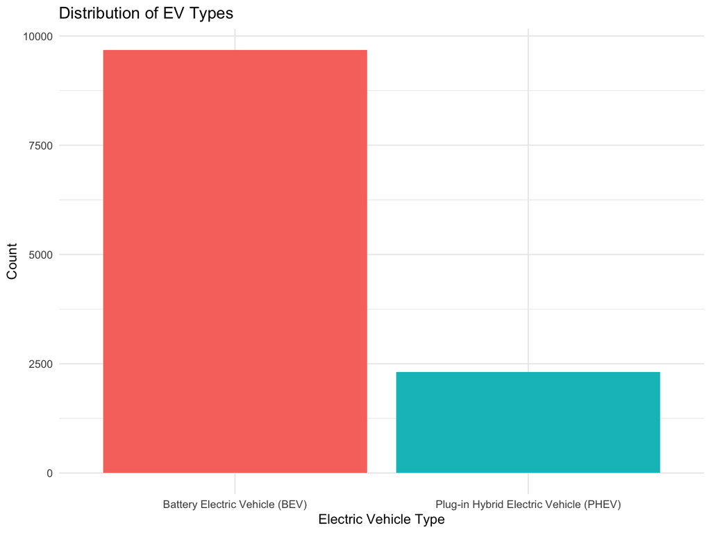

# Which are the top 10 most common EV makes in Washington?

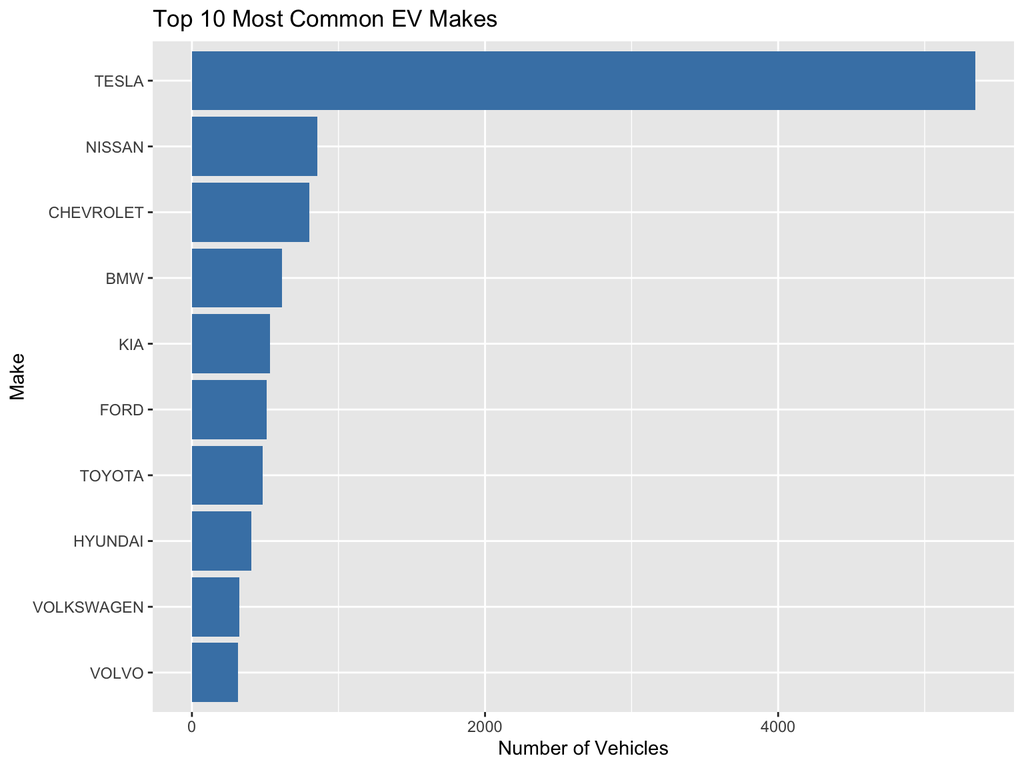

# What are the top 10 most common EV models in Washington?

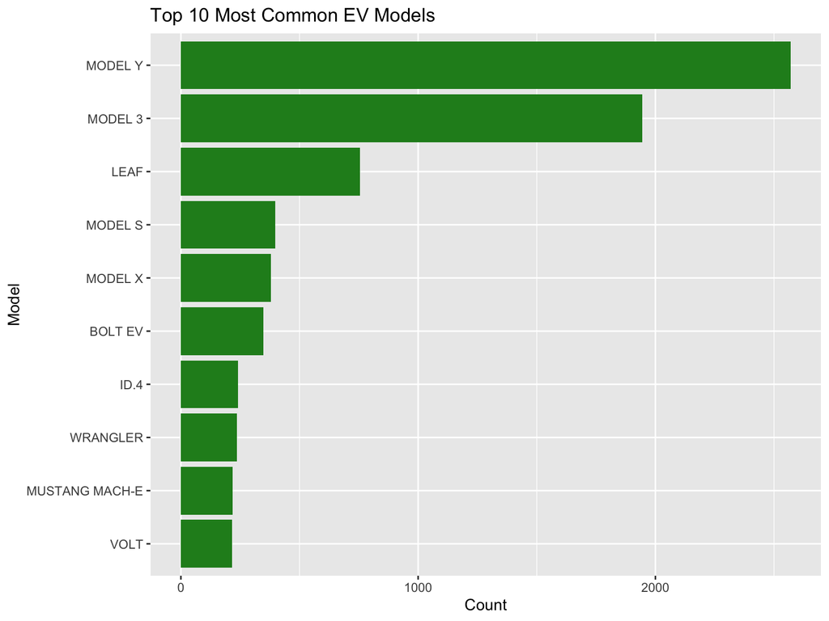

# What Are the Most Preferred Electric Utility Providers for EV Owners?

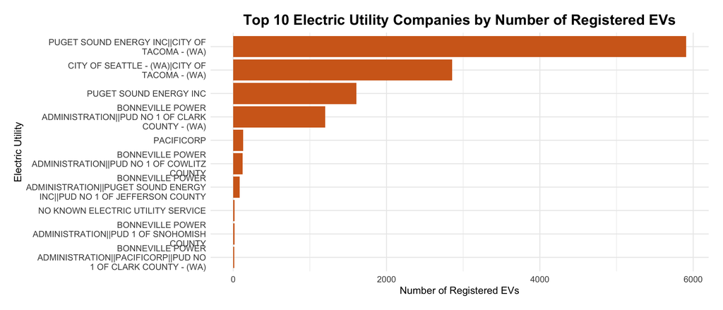

# How does EV adoption vary by county? How does the distribution of electric vehicle types vary among the top five counties with the highest EV adoption?

[interactive chart not shown]

Summary conclusion

EV adoption varies significantly by county, with King County having the highest adoption rate with 8764 EVs, followed by Clark (1212 EVs), Kitsap (676 EVs), Snohomish (498 EVs), Thurston (375 EVs), Yakima (135 EVs), and Cowlitz (123 EVs). The adoption rate decreases progressively from King County to Cowlitz County, indicating that certain regions have stronger adoption trends.

# What trends can be observed in EV registrations over different model years?

[interactive chart not shown]

Summary conclusion

The graph shows that EV registrations were minimal from 2000 to around 2010, with almost no recorded registrations. Between 2010 and 2015, there was a slight increase, but the numbers remained relatively low. A noticeable upward trend began around 2015, with a significant surge starting in 2018. The peak occurred in 2022, reaching approximately 3,000 registrations. After 2022, there was a sharp decline, with registrations dropping significantly by 2025.

# Which cities have the highest number of registered electric vehicles, and how can spatial mapping illustrate all of Washington cities in EV adoption?

[interactive chart not shown]

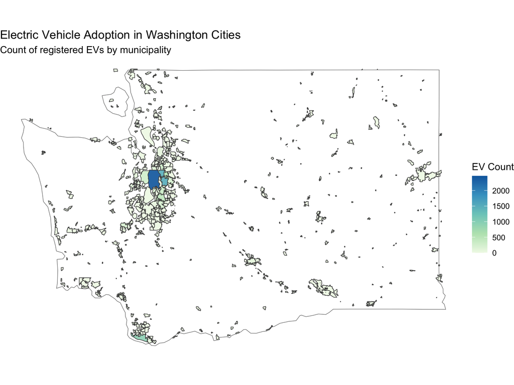

Summary conclusion

Seattle has the highest number of registered electric vehicles, with approximately 2,500 EVs. Bellevue and Kirkland follow, each with around 1,500 EVs. Vancouver has about 1,000 EVs, and Redmond has the lowest among the five cities shown, with around 500 EVs.

### Are certain EV manufacturers dominant in specific counties or regions?

[interactive chart not shown]

Summary conclusion

The bar chart illustrates the number of Tesla vehicles registered across various counties in Washington. King County has the highest number of Tesla registrations (4074 EVs), far surpassing any other county. The data shows a significant drop in Tesla registrations after King County, with Clark (501 EVs), Snohomish (258 EVs), and Kitsap (234 EVs) Counties following but with noticeably lower numbers.

# *III. Conclusion*

*Findings and Conclusions Table*

[output not shown]

# *IV. References*

The original (unfiltered) database for this project can be downloaded at https://data.wa.gov/api/views/f6w7-q2d2/rows.csv?accessType=DOWNLOAD

Thank you for listening!